# Metabolic correlation network analysis

Andreas Mock

National Center for Tumor Diseases (NCT), Heidelberg

andreas.mock@nct-heidelberg.de

27 Oktober 2020

#### Abstract

Correlation network analysis has been successfully applied in comparative transcriptomics to reveal changes in meaningful biological subpathways (modules). This markdown document describes an adaptation for metabolomic data analysis.

#### Package

MetaboDiff 0.9.5

```r
library(MetaboDiff)
```

# 1 Part I: Implementation of WGNCA for metabolomics

The following workflow was adapted from the weighted gene co-expression analysis (WGCNA) proposed by Langfelder and Horvarth and makes use of the functions of the corresponding WGCNA R package.

Zhang, B., & Horvath, S. (2005). A general framework for weighted gene co-expression network analysis. Statistical Applications in Genetics and Molecular Biology, 4(1), Article17. http://doi.org/10.2202/1544-6115.1128

Langfelder, P., & Horvath, S. (2008). WGCNA: an R package for weighted correlation network analysis. BMC Bioinformatics, 9, 559–559. http://doi.org/10.1186/1471-2105-9-559

As for the MetaboDiff tutorial, the implementation is demonstrated using the example data from a study by Priolo and colleagues in which the authors used the service of Metabolon® to compare the tissue metabolome of 40 prostate cancers with 16 normal prostate specimens. The MetaboDiff packages contains this data within the object `met_example`.

Priolo, C., Pyne, S., Rose, J., Regan, E. R., Zadra, G., Photopoulos, C., et al. (2014). AKT1 and MYC Induce Distinctive Metabolic Fingerprints in Human Prostate Cancer. Cancer Research, 74(24), 7198–7204. http://doi.org/10.1158/0008-5472.CAN-14-1490

In the MetaboDiff tutorial, all steps for WGCNA were performed within a set of functions connected by pipes:

- `diss_matrix` - construction of dissimilarity matrix
- `identify_modules` - identification of metabolic correlation modules
- `name_modules` - name metabolic correlation modules
- `calculate_MS` - calculation of module signficance to relate sample traits to modules

```r
met_example <- met_example %>%
    diss_matrix %>%
    identify_modules(min_module_size=5) %>%
    name_modules(pathway_annotation="SUB_PATHWAY") %>%
    calculate_MS(group_factors=c("tumor_normal","random_gender"))
```

The individual steps will be explained as follows.

## 1.1 Construction of dissimilarity matrix

The first step in constructing a metabolic correlation network is the creation of a dissimilarity matrix. Biweight midcorrelation was used as a similiarity measure as it is more robust to outliers than the absolute correlation coefficient. This choice is important, as we do not expect metabolites to be correlated in all patients.

Zheng, C.-H., Yuan, L., Sha, W., & Sun, Z.-L. (2014). Gene differential coexpression analysis based on biweight correlation and maximum clique. BMC Bioinformatics, 15 Suppl 15(Suppl 15), S3. http://doi.org/10.1186/1471-2105-15-S15-S3

The core concept of the so called “weighted” correlation analysis by Langfelder and Horvarth is that instead of defining a “hard” threshold (e.g. an absolute correlation coefficient > 0.8) to decide whether a node to connected to another, the adjacency `a` is defined by raising the similarity `s` to a power `beta` (“soft” threshold):

$$\begin{equation}
a_{ij} = s_{ij}^\beta
\end{equation}$$

Lastly, the dissimilarity measure `w` is defined by

$$\begin{equation}
w_{ij} = 1 - a_{ij}
\end{equation}$$

For detailed rationale of this approach, please see Zhang and Horvath. For metabolic networks, we identified that a beta value of 3 was the lowest power for which the scale-free topology of the topology was met_example.

Zhang, B., & Horvath, S. (2005). A general framework for weighted gene co-expression network analysis. Statistical Applications in Genetics and Molecular Biology, 4(1), Article17. http://doi.org/10.2202/1544-6115.1128

The function `diss_matrix` creates the dissimilarity measure for the `met_example` objects and saves it in the metadata slot

```r
met_example <- diss_matrix(met_example)
```

## 1.2 Identification of metabolic correlation modules

To identify metabolic correlation modules, metabolites are next clustered based on the dissimilarity measure where branches of the dendrogram correspond to modules. Ultimately, modules are detected by applying a branch cutting method with a minimal module size of 5 metabolites. We employed the dynamic branch cut method developed by Langfelder and colleagues, as constant height cutoffs exhibit suboptimal performance on complicated dendrograms. Figure 1 shows the hierarchical clustering and corresponding modules after branch cutting.

Langfelder, P., Zhang, B., & Horvath, S. (2008). Defining clusters from a hierarchical cluster tree: the Dynamic Tree Cut package for R. Bioinformatics, 24(5), 719–720. http://doi.org/10.1093/bioinformatics/btm563.

```r
met_example <- identify_modules(met_example,
                       min_module_size=5)
```

```
##  ..cutHeight not given, setting it to 0.991  ===>  99% of the (truncated) height range in dendro.
##  ..done.
```

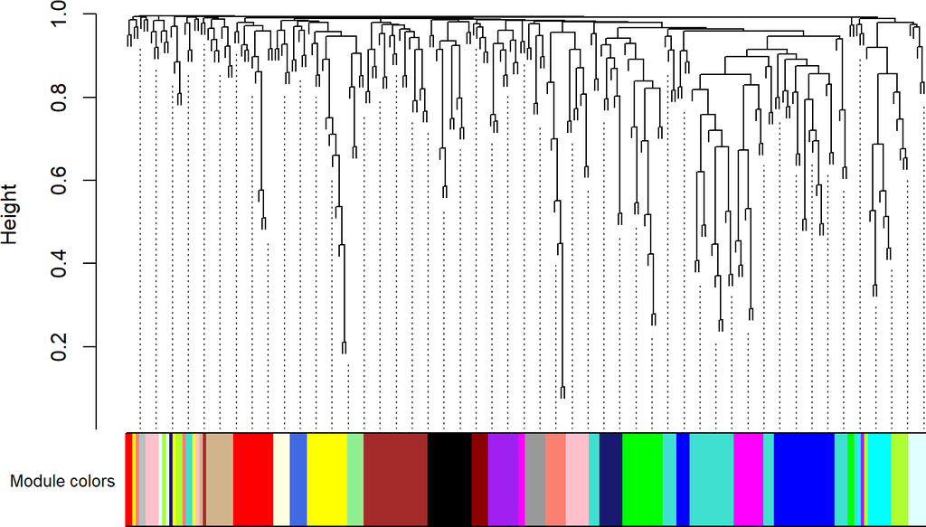

Figure 1: Hierarchical clustering of metabolites  
The different colors represent the modules identified by the dynamic branch cutting method.

```r
WGCNA::plotDendroAndColors(metadata(met_example)$tree,
                    metadata(met_example)$module_color_vector,
                    'Module colors',
                    dendroLabels = FALSE,
                    hang = 0.03,
                    addGuide = TRUE,
                    guideHang = 0.05, main='')
```

The relation between the identified metabolic correlation modules can be visualized by a dendrogram of their *eigenmetabolite* (figure 2). The module *eigenmetabolite* is defined as the first principal component of the metabolic measurements in the respective module.

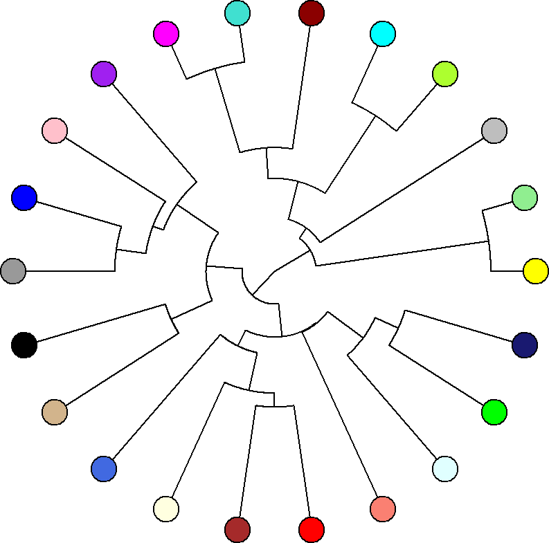

Figure 2: Hierarchy of metabolic correlation modules as revealed by the clustering of module eigenmetabolite  
Each node represents a metabolic correlation module.

```r
par(mar=c(2,2,2,2))
ape::plot.phylo(ape::as.phylo(metadata(met_example)$METree),
           type = 'fan',
           show.tip.label = FALSE,
           main='')
ape::tiplabels(frame = 'circle',
          col='black',
          text=rep('',length(unique(metadata(met_example)$modules))),
          bg = WGCNA::labels2colors(0:21))
```

```r
# number of metabolites per module
table(metadata(met_example)$modules)
```

```
##
##  0  1  2  3  4  5  6  7  8  9 10 11 12 13 14 15 16 17 18 19 20 21
##  2 30 22 20 15 14 14 13 12 11 10  9  9  8  8  8  7  6  5  5  5  5
```

## 1.3 Name metabolic correlation modules

To enable a better interpretation of metabolic correlation modules, modules are named according to the most abundant pathway annotation in a module (figure 3).

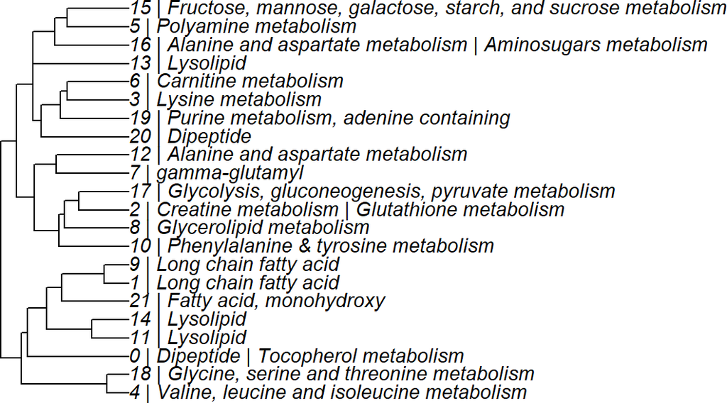

Figure 3: Hierarchy of metabolic correlation modules  
Modules are named according to the most abundant pathway annotation in a module. Module 0 comprises the two metabolites without a significant interaction.

```r
# calculate module significance
met_example <- name_modules(met_example,
                   pathway_annotation = "SUB_PATHWAY")

# plot phylogram with names
ape::plot.phylo(ape::as.phylo(metadata(met_example)$METree), cex=0.9)
```

## 1.4 Calculation of module signficance to relate sample traits to modules

An advantage of correlation network analysis is the possibility to integrate external information. At the lowest hierarchical level, *metabolite significance* (MetS) measures can be defined as the statistical significance (i.e. p-value, $p_i$) between the $i$-th node profile (metabolite) $x_i$ and the sample trait $T$

$$\begin{equation}
MetS_i = -log~p_i
\end{equation}$$

*Module significance* (MS) in turn can be determined as the average absolute metabolite significance measure. This conceptual framework can be adapted to any research question.

```r
met_example <- calculate_MS(met_example,
                   group_factors = c("tumor_normal","random_gender"))
```

Figure 4 shows that metabolic correlation module 2 (Creatine metabolism / Glutathione metabolism) was significantly associated with the tumor vs. normal comparison in the example data.

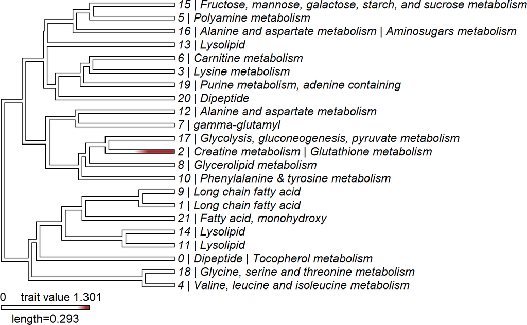

Figure 4: Association of tumor vs normal trait with metabolic correlation modules  
Module 2 (Creatine metabolism / Glutathione metabolism) showed a significant module significance with a higher relative abundance in normal prostate tissues. P-values were not adjusted for multiple testing.

```r
MS_plot(met_example,
        group_factor="tumor_normal",
        p_value_cutoff=0.05,
        p_adjust=FALSE)
```

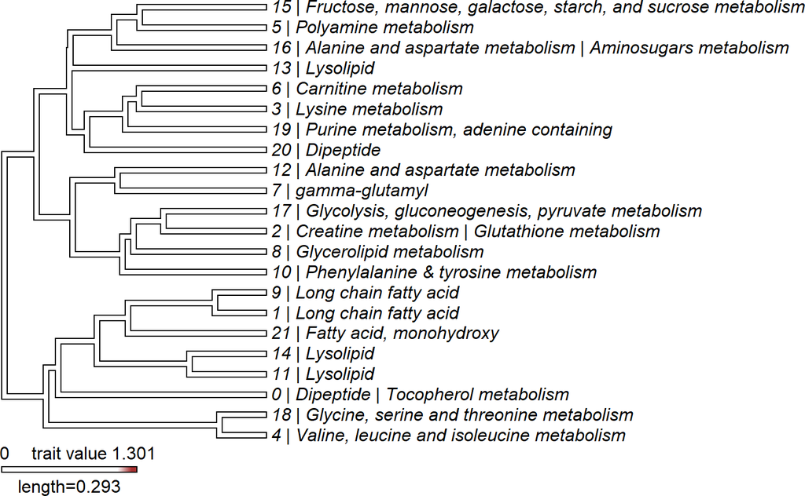

Figure 5: Association of random trait with metabolic correlation modules  
No significant module significance can be observed. P-values were not adjusted for multiple testing.

```r
MS_plot(met_example,
        group_factor="random_gender",
        p_value_cutoff=0.05,
        p_adjust=FALSE)
```

## 1.5 Exploration of individual metabolites within correlation module

Assessing the module significance for different sample traits facilitates an understanding of individual metabolic correlation modules. As for metabolomics, we are next interested in the role of the individual metabolite within module. To this end, Langfelder and Horvath suggest a ‘fuzzy’ measure of *module membership* defined as

$$\begin{equation}
K^q = |cor(x_i,E^q)|
\end{equation}$$

where $x_i$ is the profile of metabolite $i$ and $E^q$ is the eigenmetabolite of module $q$. Based on this definition, $K$ describes how closely related metabolite $i$ is to module $q$. A meaningful visualization is consequently plotting the module membership over the p-value of the respective $MetS$ measure (`MOI_plot`). As a third dimension, the color is scaled according to the effect size (i.e. difference in means).

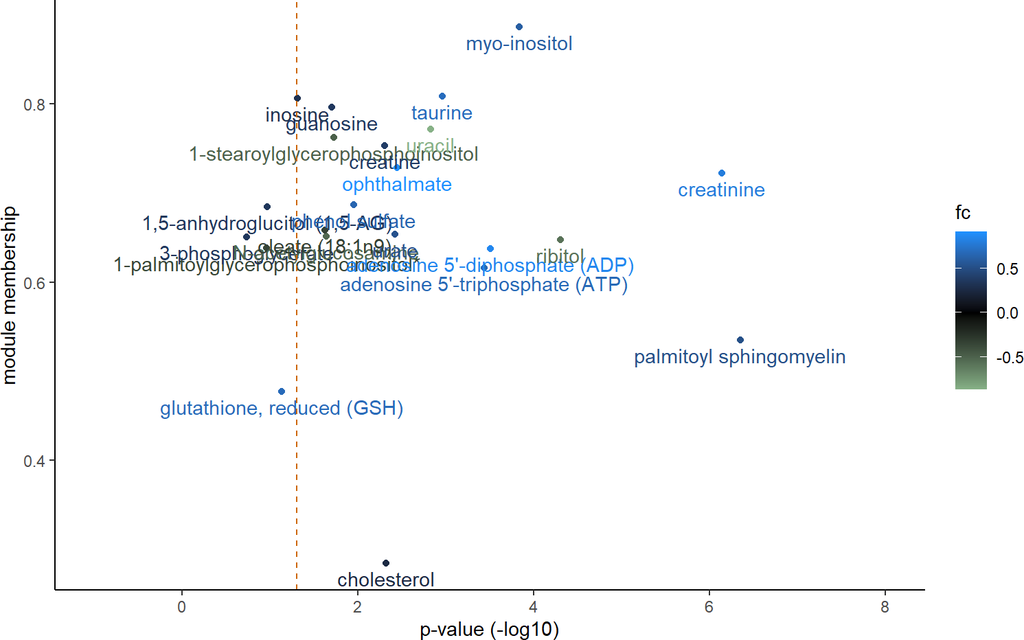

Figure 6: Association of individual metabolites within module 2  
Myo-inositol is most tightly linked to the module (e.g. eigenmetabolite).

```r
MOI_plot(met_example,
         group_factor="tumor_normal",
         MOI = 2,
         label_colors=c("darkseagreen","dodgerblue"),
         p_adjust = FALSE) + xlim(c(-1,8))
```

For more information about the application and interpretation of metabolic correlation networks, please refer to the package vignette ‘Case_study’.